# Práctica 9

# Práctica 9: Reconstrucción filogenética

## Objetivos:

Obtener una filogenia calibrada de homininos y algunos primates, a partir de secuencias mitocondriales.

## Ejercicio 1:

### 1.1 Leer los datos en R

```r
library(phangorn)
mtdna <- read.phyDat('../../data/mtDNA.fasta', format = 'fasta')
glance(mtdna)
```

```
  nseq nchar unique_site_pattern parsimony_informative_sites const_sites
1   42 16603                 974                        2047       13482
```

Sería sensato reducir el conjunto de datos. ¿Qué secuencias eliminarías? Si quieres, puedes intentarlo con la función subset().

### 1.2 Escoger el modelo de evolución

```r
modelos <- modelTest(mtdna, control = pml.control(trace = 0))
```

```r
modelos <- modelTest(mtdna, control = pml.control(trace = 0),
                     multicore = TRUE, mc.cores = 2)
```

Se obtiene un marco de datos. Nos tenemos que fijar en el AIC o BIC. Al ser un marco de datos y lo podemos ordenar. > modelos [order(modelos$BIC),]

Para extraer más datos usamos estos comandos.

> fit <- as.pml(modelos, ‘GTR+G(4)+I’) fit

> fit <- as.pml(modelos, ‘BIC’) fit

1.2.1 NJ y UPGMA

Para ver mejor el árbol #| fig-width: 10 #| fig-height: 10 Cambianod los números ajustamos a la mejor visualización.

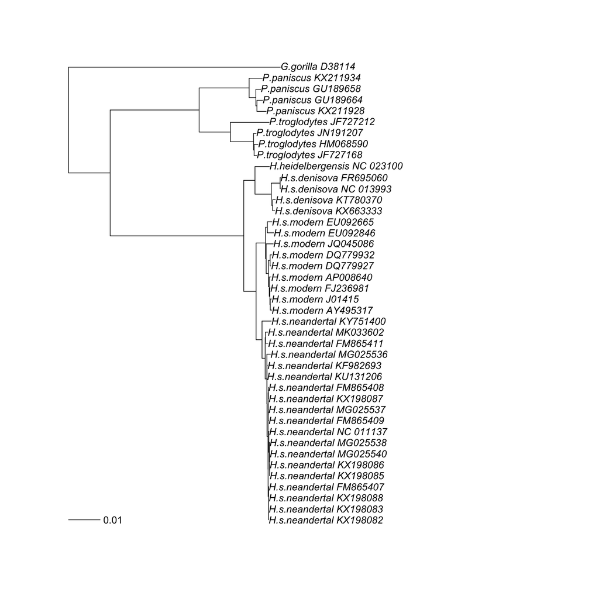

```r
mt_nj    <-    NJ(dist.dna(as.DNAbin(mtdna), model = 'TN93', gamma = 0.93))
mt_upgma <- upgma(dist.dna(as.DNAbin(mtdna), model = 'TN93', gamma = 0.93))
plot(midpoint(mt_nj))
add.scale.bar()
```

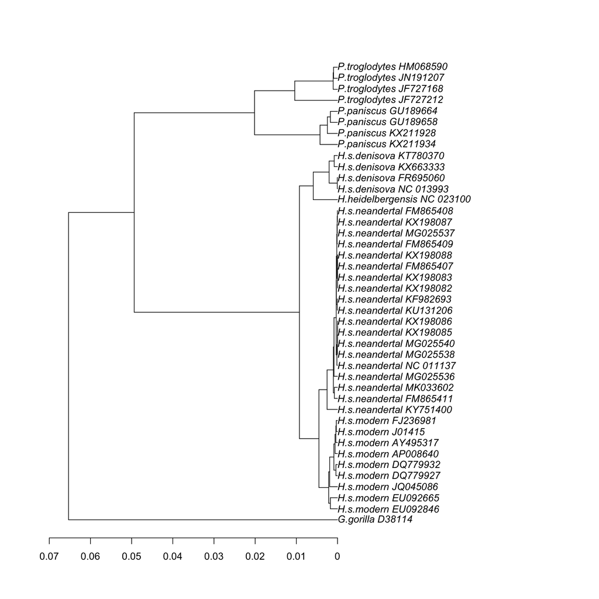

```r
plot(mt_upgma)
axisPhylo()
```

¿Por qué usamos midpoint() al representar gráficamente el árbol de NJ?

### 1.3 Enraizar el árbol

```r
enraizado <- root(mt_nj, 'G.gorilla_D38114')
```

Se ha creado una copia del árbol de arriba pero con la raiz. Para visualizarlo en la consola se pone: > plot(midpoint(enraizado))

```r
veros <- pml_bb(mtdna, model = 'GTR+G(4)+I',
                control = pml.control(trace = 0))
```

Enraizamos el árbol con gorila como outgroup.

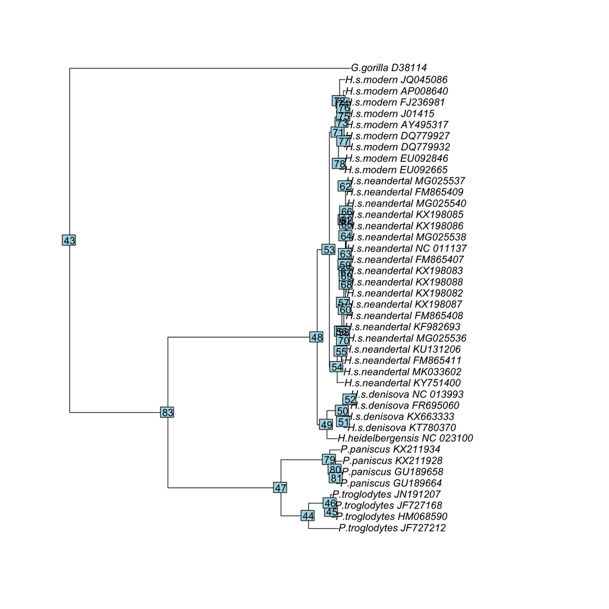

```r
mt_ml <- root(veros$tree, 'G.gorilla_D38114')
plot(midpoint(mt_ml))
nodelabels()
```

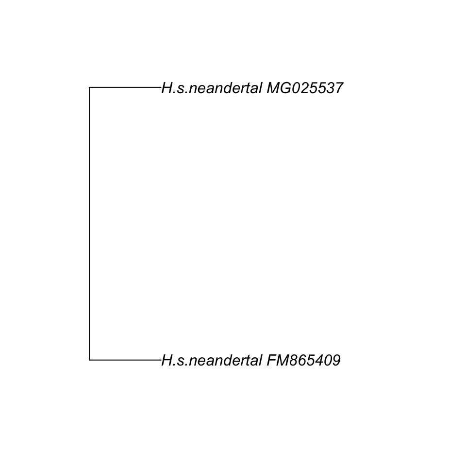

```r
homo <- extract.clade(mt_ml, 62)
plot(midpoint(homo))
```

### 1.4 Con datación de puntas (tip dating)

```r
fechas <- c(0, 0, 0, 0, 0, 0, 0, 0, 0,
              -400000,
              -39000, -50000, -110000, -110000,
              -39820, -40096, -38515, -38310, -39000, -40000, -41210,
              -42430, -42540, -43230, -43780, -44290, -44770, -49000,
              -50000, -82752, -65000, -122287, -110450,
              0, 0, 0, 0, 0, 0, 0, 0, 0)
setNames(fechas, names(mtdna))
```

```
           G.gorilla_D38114      P.troglodytes_JF727212
                          0                           0
     P.troglodytes_JN191207      P.troglodytes_JF727168
                          0                           0
     P.troglodytes_HM068590         P.paniscus_KX211934
                          0                           0
        P.paniscus_KX211928         P.paniscus_GU189658
                          0                           0
        P.paniscus_GU189664 H.heidelbergensis_NC_023100
                          0                     -400000
     H.s.denisova_NC_013993       H.s.denisova_FR695060
                     -39000                      -50000
      H.s.denisova_KX663333       H.s.denisova_KT780370
                    -110000                     -110000
    H.s.neandertal_KX198085     H.s.neandertal_KX198086
                     -39820                      -40096
    H.s.neandertal_MG025538    H.s.neandertal_NC_011137
                     -38515                      -38310
    H.s.neandertal_FM865409     H.s.neandertal_FM865407
                     -39000                      -40000
    H.s.neandertal_KX198088     H.s.neandertal_KX198083
                     -41210                      -42430
    H.s.neandertal_MG025540     H.s.neandertal_MG025536
                     -42540                      -43230
    H.s.neandertal_MG025537     H.s.neandertal_KX198087
                     -43780                      -44290
    H.s.neandertal_KX198082     H.s.neandertal_FM865408
                     -44770                      -49000
    H.s.neandertal_KU131206     H.s.neandertal_KF982693
                     -50000                      -82752
    H.s.neandertal_FM865411     H.s.neandertal_KY751400
                     -65000                     -122287
    H.s.neandertal_MK033602         H.s.modern_EU092846
                    -110450                           0
        H.s.modern_EU092665         H.s.modern_JQ045086
                          0                           0
        H.s.modern_DQ779927         H.s.modern_DQ779932
                          0                           0
        H.s.modern_AP008640         H.s.modern_AY495317
                          0                           0
          H.s.modern_J01415         H.s.modern_FJ236981
                          0                           0
```

```r
fit_td <- pml_bb(mtdna, model = 'GTR+G(4)+I', method = 'tipdated',
                 tree = enraizado,
                 tip.dates = fechas, rearrangement = 'NNI',
                 control = pml.control(trace = 0))
```

El objetivo es que sea “ultramétrico”, que se respete la edad/ tiempo en el apareció.

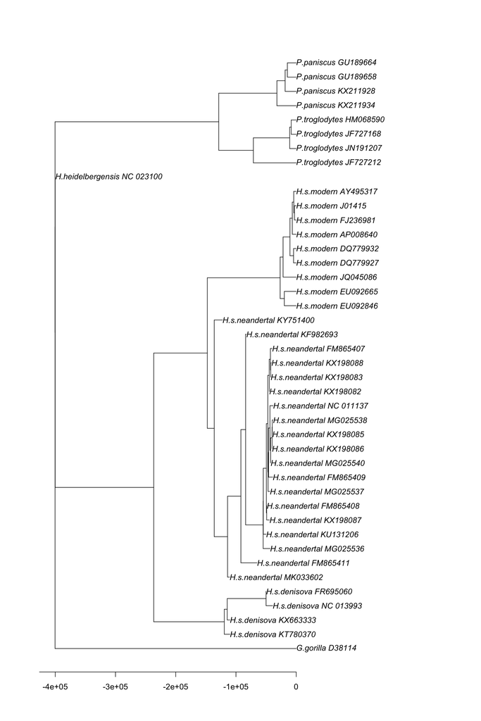

```r
plot(fit_td)
```

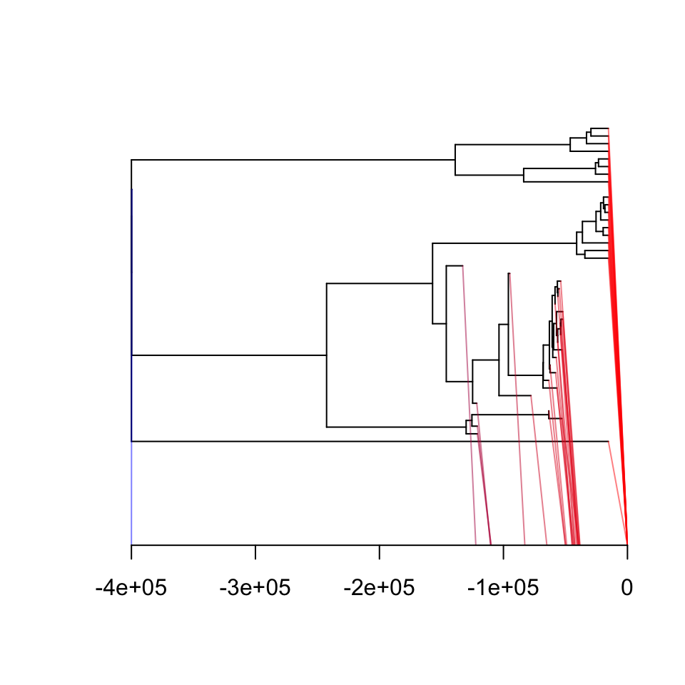

```r
plotTreeTime(fit_td$tree, fechas)
```

estimate.mu() estimate.date() Estima la edad en función del número de mutaciones que le faltan a las secuencias arcaicas. Importante que esten todas las fechas en las mismas unidades.

Objetivo: Ver a que velocidad está mutando el ADN mitocondrial y estimlar fechas y edades.

```r
estimate.mu(mt_ml, fechas, p.tol = 0.05)
```

```
[1] 2.188398e-08
```

```r
estimate.dates (mt_ml, fechas, mu = estimate.mu(mt_ml, fechas),
               min.date = .Machine$double.xmax, show.steps = 0,
               opt.tol = 1e-8, nsteps = 1000,
               lik.tol = 0, is.binary.phylo(mt_ml))
```

```
 [1]   0.000000e+00   0.000000e+00   0.000000e+00   0.000000e+00   0.000000e+00
 [6]   0.000000e+00   0.000000e+00   0.000000e+00   0.000000e+00  -4.000000e+05
[11]  -3.900000e+04  -5.000000e+04  -1.100000e+05  -1.100000e+05  -3.982000e+04
[16]  -4.009600e+04  -3.851500e+04  -3.831000e+04  -3.900000e+04  -4.000000e+04
[21]  -4.121000e+04  -4.243000e+04  -4.254000e+04  -4.323000e+04  -4.378000e+04
[26]  -4.429000e+04  -4.477000e+04  -4.900000e+04  -5.000000e+04  -8.275200e+04
[31]  -6.500000e+04  -1.222870e+05  -1.104500e+05   0.000000e+00   0.000000e+00
[36]   0.000000e+00   0.000000e+00   0.000000e+00   0.000000e+00   0.000000e+00
[41]   0.000000e+00   0.000000e+00  8.988466e+307  2.996155e+307  7.490388e+306
[46]  1.498078e+307  5.992310e+307  5.992310e+307  2.996155e+307  1.997437e+307
[51]  9.987184e+306  9.987184e+306  3.994874e+307  1.997437e+307  9.987184e+306
[56]  4.993592e+306  3.329061e+306  8.322653e+305  2.219374e+306  1.109687e+306
[61]  1.479583e+306  7.397914e+305  9.863886e+305  4.931943e+305  2.465971e+305
[66]  1.232986e+305  4.931943e+305  2.465971e+305  1.232986e+305  1.664531e+306
[71]  2.663249e+307  1.331625e+307  8.877497e+306  4.438748e+306  2.219374e+306
[76]  1.109687e+306  4.438748e+306  1.331625e+307  2.996155e+307  1.498078e+307
[81]  7.490388e+306  6.164928e+304
```